# Project: Investigate a Dataset (a TMDb Movie Dataset ) by Mohamed Atef

### 9. As per popularity score which movie is most famous?

```python
movies.sort_values(by = 'popularity', ascending = False).loc[:,['popularity','original_title']][0:10]
```

|  | popularity | original_title |
| --- | --- | --- |
| 0 | 32.985763 | Jurassic World |
| 1 | 28.419936 | Mad Max: Fury Road |
| 629 | 24.949134 | Interstellar |
| 630 | 14.311205 | Guardians of the Galaxy |
| 2 | 13.112507 | Insurgent |
| 631 | 12.971027 | Captain America: The Winter Soldier |
| 1329 | 12.037933 | Star Wars |
| 632 | 11.422751 | John Wick |
| 3 | 11.173104 | Star Wars: The Force Awakens |
| 633 | 10.739009 | The Hunger Games: Mockingjay - Part 1 |

### 10. As per Average vote score which movie is most famous?

```python
movies.sort_values(by = 'vote_average' ,ascending = False).loc[:,['vote_average','original_title']][0:10]
```

|  | vote_average | original_title |
| --- | --- | --- |
| 609 | 8.4 | The Jinx: The Life and Deaths of Robert Durst |
| 7948 | 8.4 | Stop Making Sense |
| 4178 | 8.4 | The Shawshank Redemption |
| 7269 | 8.3 | The Godfather |
| 9315 | 8.2 | For All Mankind |
| 650 | 8.2 | Whiplash |
| 4179 | 8.1 | Forrest Gump |
| 9758 | 8.1 | The Godfather: Part II |
| 4177 | 8.1 | Pulp Fiction |
| 2389 | 8.1 | Bill Cunningham New York |

### 11. As per Average vote score which Actor/Actress is most famous?

```python
movies_cast.sort_values(by = 'vote_average' ,ascending = False).loc[:,['vote_average','cast']][0:10]
```

|  | vote_average | cast |
| --- | --- | --- |
| 23609 | 8.4 | Jerry Harrison |
| 1643 | 8.4 | Lynda Obst |
| 12069 | 8.4 | William Sadler |
| 12068 | 8.4 | Bob Gunton |
| 23610 | 8.4 | Steven Scales |
| 12070 | 8.4 | Clancy Brown |
| 12067 | 8.4 | Morgan Freeman |
| 12066 | 8.4 | Tim Robbins |
| 23606 | 8.4 | David Byrne |
| 1639 | 8.4 | Robert Durst |

### 12. Movies which have earned highest revenue.

```python
movies.sort_values(by = 'gross_profit_adj',ascending = False).loc[:,['gross_profit_adj', 'original_title']][0:10]
```

|  | gross_profit_adj | original_title |
| --- | --- | --- |
| 1329 | 17.840305 | Star Wars |
| 1386 | 16.756813 | Avatar |
| 5231 | 14.433001 | Titanic |
| 10594 | 13.727786 | The Exorcist |
| 9806 | 12.079128 | Jaws |
| 8889 | 11.347489 | E.T. the Extra-Terrestrial |
| 3 | 11.021947 | Star Wars: The Force Awakens |
| 8094 | 9.916937 | The Net |
| 10110 | 9.877715 | One Hundred and One Dalmatians |
| 7309 | 8.762903 | The Empire Strikes Back |

### 13. Most Frequent Runtime of movies

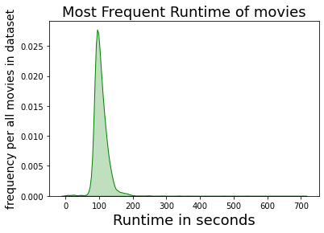

```python
sns.kdeplot(movies['runtime'], shade = True, color = 'g');
plt.xlabel('Runtime in seconds',fontsize = 18);
plt.ylabel('frequency per all movies in dataset', fontsize =14);
plt.title('Most Frequent Runtime of movies', fontsize = 18);
```

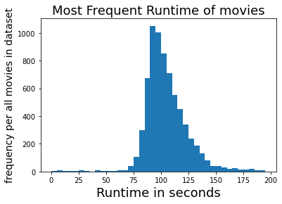

```python
binval = np.arange(0,200,5)
plt.hist(movies['runtime'],bins = binval);
plt.xlabel('Runtime in seconds',fontsize = 18);
plt.ylabel('frequency per all movies in dataset', fontsize =14);
plt.title('Most Frequent Runtime of movies', fontsize = 18);
```

### 14. Most famous action directors

```python
action=genres_movies[genres_movies['genres'] == 'Action'] #filter dataframe by Action Genre
```

```python
#Use groupby to sum up by director & then sort by gross profit in descending order
action.groupby('director').sum().sort_values(by = 'gross_profit_adj',ascending = False)['gross_profit_adj'][0:10]
```

```
director
George Lucas         33.506443
Peter Jackson        26.805140
James Cameron        24.780044
Steven Spielberg     21.030381
Michael Bay          20.252172
Roland Emmerich      16.090665
Guy Hamilton         15.681047
Christopher Nolan    15.381549
J.J. Abrams          15.074054
Joss Whedon          13.980535
Name: gross_profit_adj, dtype: float64
```

### 15. Most famous Actors in Action genre.

```python
genres_movies_cast = pd.merge(genres_movies,cast,how = 'inner', on = 'id') #merge dataframe genre_movies & cast
```

```python
#filter data by Action genere
action_cast=genres_movies_cast[genres_movies_cast['genres'] == 'Action']
```

```python
#group the data by cast take sum of it & then sort it accoring to popularity score in descending order.
action_cast.groupby('cast').sum().sort_values(by = 'popularity', ascending = False)['popularity'][0:10]
```

```
cast
Harrison Ford            61.072100
Samuel L. Jackson        53.610413
Arnold Schwarzenegger    52.866660
Tom Hardy                48.581000
Jason Statham            47.446214
Chris Pratt              47.296968
Chris Evans              46.219419
Orlando Bloom            43.405702
Bruce Willis             42.707748
Scarlett Johansson       42.199309
Name: popularity, dtype: float64
```

```python
genres_cast = pd.merge(genres,cast, how = 'inner', on = 'id')
```

### 16. Which production companies have made most of the movies

```python
movies_prod_companies['production_companies'].value_counts()[0:10]
```

```
Warner Bros.                              458
Universal Pictures                        456
Paramount Pictures                        390
Twentieth Century Fox Film Corporation    262
Columbia Pictures                         253
New Line Cinema                           199
Metro-Goldwyn-Mayer (MGM)                 194
Walt Disney Pictures                      159
Touchstone Pictures                       154
Columbia Pictures Corporation             144
Name: production_companies, dtype: int64
```

### 17.Most frequent Keywords used in every genres.

```python
movies_key = pd.merge(movies , keywords , how = 'inner' , on = 'id')
```

### I have merged two DataFrames for answering question num 17.

```python
genres_keywords = pd.merge(genres , keywords , how = 'inner', on = 'id')
```

```python
genres_keywords.head(20)
```

|  | id | genres | keywords |
| --- | --- | --- | --- |
| 0 | 135397 | Action | monster |
| 1 | 135397 | Action | dna |
| 2 | 135397 | Action | tyrannosaurus rex |
| 3 | 135397 | Action | velociraptor |
| 4 | 135397 | Action | island |
| 5 | 135397 | Adventure | monster |
| 6 | 135397 | Adventure | dna |
| 7 | 135397 | Adventure | tyrannosaurus rex |
| 8 | 135397 | Adventure | velociraptor |
| 9 | 135397 | Adventure | island |
| 10 | 135397 | Science Fiction | monster |
| 11 | 135397 | Science Fiction | dna |
| 12 | 135397 | Science Fiction | tyrannosaurus rex |
| 13 | 135397 | Science Fiction | velociraptor |
| 14 | 135397 | Science Fiction | island |
| 15 | 135397 | Thriller | monster |
| 16 | 135397 | Thriller | dna |
| 17 | 135397 | Thriller | tyrannosaurus rex |
| 18 | 135397 | Thriller | velociraptor |
| 19 | 135397 | Thriller | island |

### Most common keywords used in all the genres

```python
keywords['keywords'].value_counts()[0:10]
```

```
based on novel          245
independent film        245
sex                     239
woman director          187
murder                  172
sport                   161
nudity                  135
new york                131
duringcreditsstinger    128
female nudity           127
Name: keywords, dtype: int64
```

### 18. Older or newer movies get more popularity score

```python
#group data by release year take the median of all the numeric columns
groupby_year=movies.groupby('release_year').median()
```

```python
#get release year column back into dataframe for visualization
groupby_year['release_year'] = groupby_year.index.get_level_values(0)
```

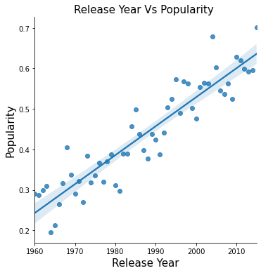

```python
plt.figure(figsize = (13,9)) #set a figure size
sns.lmplot(x = 'release_year', y = 'popularity', data = groupby_year); #plot a lineplot
#gives names to x-axis , y-axis & the title
plt.xlabel('Release Year', fontsize = 15);
plt.ylabel('Popularity', fontsize = 15);
plt.title('Release Year Vs Popularity ',fontsize = 15);
```

# Comment of Release Year Vs Popularity figure :

### According to the last visulaization, it's clearly appear that the popularity of the movie differ according to the release year. The recently released movies are more popular than the older ones. This may happen due to the recent changes in social media and the different types of used channels which deliver the movies to the followers via Instagram, Youtube, Twitter, Facebook and Televisions. In a previous time, between 1960 till 1990, users just depended on cinema, and telivision. But today, we can watch movies using Netflix and see the promo videos on any type of the previously mentioned social media accounts.

## Conclusions

> **As per the analysis phase, I have found**

**Trend of releasing movies has increased over the years.**

**By popularity Score**

> Most Popular Movie is Jurrassic World

> Most Famous Genre is Drama

**Highest gross Profit earned**

> **Director** Steven Spielberg

> **Movie** Star Wars

> **Cast** Harrison Ford

> **Production Company** Twentieth Century Fox Film Corporation

**By Average Votes**

> **Popular Movie** The Jinx:The Life and Deaths of Robert Durst

**We can find that the results of popular movies,popular cast based on popularity score,budget,revenue,average votes received but the analysis could have been more informative if data also has details of awards received by actors or actress**

**Tagline & overview of movies are important to understand how movies emotion changes according to genres**

**Data doesn't contain any information such as movies recommended for kids,providing this data could have been useful to get information about movies,cast & genres which are famous among kids.**